# xv20220623_3_interactions_data

x.vergara

2022-06-23

# Script to generate figure #3 in the paper.

The main message of the figure is that proteins that interact together have similar CCDs. We assess this at two different levels: Interaction and community level. The conclusion in both levels is that indeed proteins interacting together have similar CCDs.

Figure outline:

A- Density plot of similarity scores between interacting pairs compared to random pairs

B- Empirical test of the mean similarity score

C- UMAP plot highlighting 4-node cliques in our data

D- Similarity tile: Clique ATM I

E- Similarity tile: Clique ATM II

F- Similarity tile: Clique FA I

G- Similarity tile: Clique FA II

H- Similarity tile: Clique mixed

This script generates the plots for figure 3

# Libraries

```r
# libraries:
library(tidyverse)
library(reshape2)
library(broom)
library(ggrepel)
library(dendextend)
library(umap)
library(igraph)
library(lsa)
library(tibble)
library(utils)
library(base)
```

# Import output files from previous scripts

```r
#DNA repair protein KO CCD analysis: Output of "xxx"
slope.protein.features.all <- readRDS("~/XV_P3_ChromDSBScreen/xv_CRISPR_screen_figures/data/xv20220317_DDR_CCD_mean_significance.rds")

#Filter previous data table only for significant CCDs: Created here
significant_proteins <- slope.protein.features.all %>% filter(model_p.adj < 0.05) %>% na.omit() #Melt
ddr_significant_CCDs_dcast <- significant_proteins %>% reshape2::dcast(gene ~ feature, value.var = "CCD_value") %>% column_to_rownames(var = "gene") #dcast

#Cluster data (named as cluster tibble): Output of "yyy"
cluster_tibble <- readRDS("~/XV_P3_ChromDSBScreen/xv_CRISPR_screen_figures/data/processed_data/xv20220623_DR_CCD_cluster_data.rds")
```

# Import BIOgrid database

```r
#Import human database
human.biogrid.database <- read.table(file = "/DATA/home/x.vergara/XV_P3_ChromDSBScreen/xv_CRISPR_screen_figures/import/BIOGRID_database/xv20220530_BIOGRID-ALL-4.4.209.tab3.txt", sep = "\t", fill = T)[c(1,4,5,8,9,12,13,14,36,37)] %>% filter(V36 == "Homo sapiens" & V37 == "Homo sapiens")

#Human physical biogrid database
h.physical.biogrid.db <- human.biogrid.database %>% filter(V13 == "physical")

#filter significant proteins
significant_protein.vector <- significant_proteins$gene %>% unique() #Vector with significant proteins
ddr.ccd.physical.biogrid.db <- h.physical.biogrid.db %>% filter(V8 %in% significant_protein.vector & V9 %in% significant_protein.vector) #Filter interaction database for interaction happening between proteins with CCDs

#Change colnames
colnames(ddr.ccd.physical.biogrid.db) <- c("interaction_ID","gene1_ID", "gene2_ID", "gene1","gene2","int_method","int_type","publication","sp_gene1", "sp_gene2")
```

Conclusion: There are 114 physically interacting protein pairs between proteins with significant CCDs

# Figure 3A-B: Calculate cosine distances for hits

### Data processing

```r
#Create a dataframe with all possible protein pairs
signif.protein.vector.ddr <- significant_proteins %>% pull(gene) %>% unique() #Get gene vector with CCDs
comb_signif.ddr <- combn(signif.protein.vector.ddr, 2, simplify = F) #Create all possible protein pairs between DR prots with CCDs
comb_signif_dt.ddr <- do.call("rbind", comb_signif.ddr) %>% as.data.frame() #Create data frame
colnames(comb_signif_dt.ddr) <- c("gene1","gene2") #Change column names

#Calculate cosine distances between each gene
cos.distance <- cosine(t(as.matrix(ddr_significant_CCDs_dcast))) #as.matrix
melt.dist.matrix <- reshape2::melt(cos.distance) #as.tibble
colnames(melt.dist.matrix) <- c("gene1", "gene2", "cos.distance") #Change column names

#Filter out redundant pairs (A-B & B-A): There is no directionality in these interactions
dist.matrix.int.biogrid <-comb_signif_dt.ddr %>% left_join(melt.dist.matrix)

#Add interaction data to all possible pairs
dist.int.partners.biogrid <- dist.matrix.int.biogrid %>%
  left_join(ddr.ccd.physical.biogrid.db) %>% #Add interaction data
  mutate(interaction = case_when(is.na(int_type) ~ FALSE, T ~ TRUE)) %>% #Does each pair interact or not?
  dplyr::group_by(gene1, gene2, cos.distance) %>% #Clean possible redundant pairs in BioGRID
  dplyr::summarise(interaction = case_when(sum(interaction) == 0 ~ F, T ~ T)) #Summarize phyisical interactions

#Sample random pairs
sample_correlations.ddr.biogrid <- tibble() #Empty tibble for sampling
n.interacting.biogrid <- dist.int.partners.biogrid %>% filter(interaction == T) %>% nrow() #Number of physical interactions in our data

#Sampling loop to select random samples of equal size as interacting pairs
   for (i in c(1:1000)){ #n=1000
  set.seed(i)
  t <- dist.int.partners.biogrid %>% ungroup() %>% sample_n(n.interacting.biogrid) %>% mutate(seed =i)
  sample_correlations.ddr.biogrid <- sample_correlations.ddr.biogrid %>% bind_rows(t)
   }

#Create density matrices for plotting later
density.matrix.datapoints <- tibble()
for (i in c(1:1000)){
  seed.unique <- filter(sample_correlations.ddr.biogrid, seed == i) %>% pull(cos.distance)%>% as.numeric()
  dens.seed.unique <- density(seed.unique, from = -1, to = 1) %>% tidy() %>% mutate(seed = i) %>% mutate(round_x = round(x, digits = 2)) %>% dplyr::group_by(round_x) %>% dplyr::summarise(mean_y = mean(y), seed = i)
  density.matrix.datapoints <- density.matrix.datapoints %>% bind_rows(dens.seed.unique)
}

#Calculate mean and sd to plot in density plots for random effects
summarise.mean.sd_sample <- density.matrix.datapoints %>% dplyr::group_by(round_x) %>% dplyr::summarise(avg_y = mean(mean_y), sd_y = sd(mean_y), counts = n())

#Calculate real interaction density data
interacting.prots <- filter(dist.int.partners.biogrid, interaction == T)
real_density_plot <- density(interacting.prots %>% pull(cos.distance), from = -1, to = 1) %>% tidy()
```

### Plotting code

#### Figure 3A: Density plots of interacting pairs

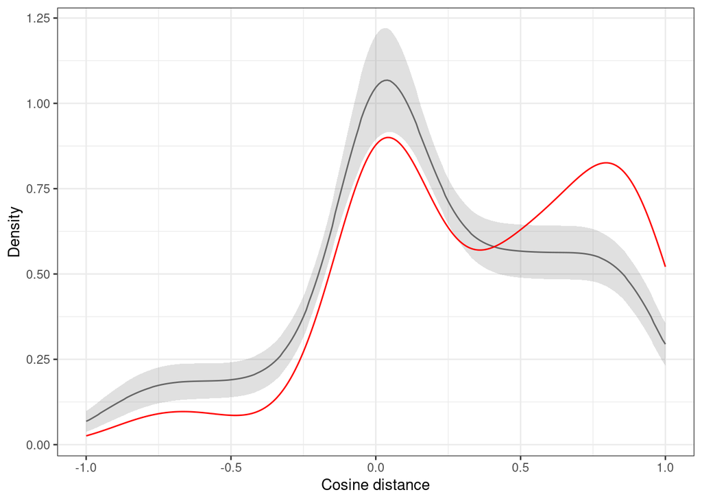

```r
ggplot(summarise.mean.sd_sample) +
  geom_ribbon(aes(round_x, ymax = avg_y + sd_y, ymin = avg_y - sd_y), alpha = 0.2, fill = "grey40") +
  geom_line(aes(round_x,avg_y), color = "grey40") +
  geom_line(data = real_density_plot, aes(x,y), color = "red") +
    theme_bw() + theme(legend.position = "top") +
  ylab("Density") + xlab("Cosine distance")
```

Figure legend: (A) Density plot comparing similarity scores (cosine distance) between interacting proteins and random protein pairs (mean +- sd)

#### Figure 3B: Random mean distribution

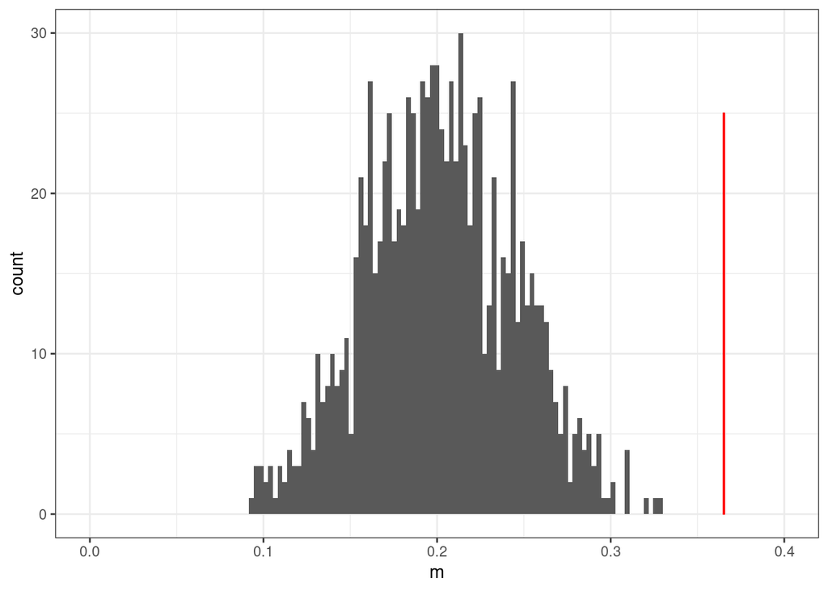

```r
#Figure 3B: Random mean distributions
sample_correlation_ddr_mean_biogrid <- sample_correlations.ddr.biogrid %>% dplyr::group_by(seed) %>% dplyr::summarise(m = mean(cos.distance))
normal_fit_data <-
real_correlation_mean_biogrid <- dist.int.partners.biogrid %>% filter(interaction == T) %>% pull(cos.distance) %>% mean()

ggplot(sample_correlation_ddr_mean_biogrid) +
  geom_histogram(aes(m), bins = 100) +
  geom_linerange(aes(real_correlation_mean_biogrid,ymin = 0, ymax = 25),color = "red") +
  coord_cartesian(expand = T, xlim = c(0,0.4)) +
  theme_bw()
```

Figure legend: (B) Random distribution of mean similarity scores. In red, mean similarity score of interacting pairs.

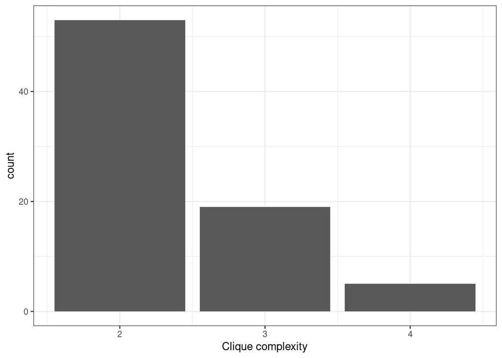

```r
#CCD data visualization as UMAP
set.seed(1) #Get consistend umap
umap.hits <- umap(ddr_significant_CCDs_dcast) #umap algorithm {umap package}
colnames(umap.hits$layout) <- c("A","B") #Change colnames
cluster_umap <- cluster_tibble %>% separate(cluster_name, into = c("pathway", "cluster"), sep = "_") #separate cluster data into pathway and interaction type
umap.hits.plot <- umap.hits$layout %>% as.data.frame() %>% rownames_to_column(var = "gene") %>% left_join(cluster_umap) #Import data from previous line
umap.hits.plot[which(umap.hits.plot$pathway == "N-synergy"),]$cluster <- 1 #Manually change nadd N-synergy clusters
umap.hits.plot[which(umap.hits.plot$gene == "CHAF1A"),]$cluster <- 2

#Find highest order cliques in the data {igraph package}
igraph_interaction_biogrid <- graph_from_data_frame(interacting.prots) #Create igraph object with interaction data

#Find maximum cliques in the data
maximum_cliques_data <- largest_cliques(igraph_interaction_biogrid) #Find largest cliques in the network (In this case five 4-node cliques)

#Find plot summary of all cliques in the data
all_max_cliques <- max_cliques(igraph_interaction_biogrid)

#Extract element numbers in the dataset
summary_max_cliques <- tibble(clique = NA, elements = NA)
for (i in 1: length(all_max_cliques)) {
  summary_max_cliques <- summary_max_cliques %>% add_row(clique = i, elements = length(names(all_max_cliques[[i]])))
}
#Summary plot
ggplot(summary_max_cliques) +
  geom_bar(aes(elements)) +
  theme_bw() + xlab("Clique complexity")
```

### Plotting script

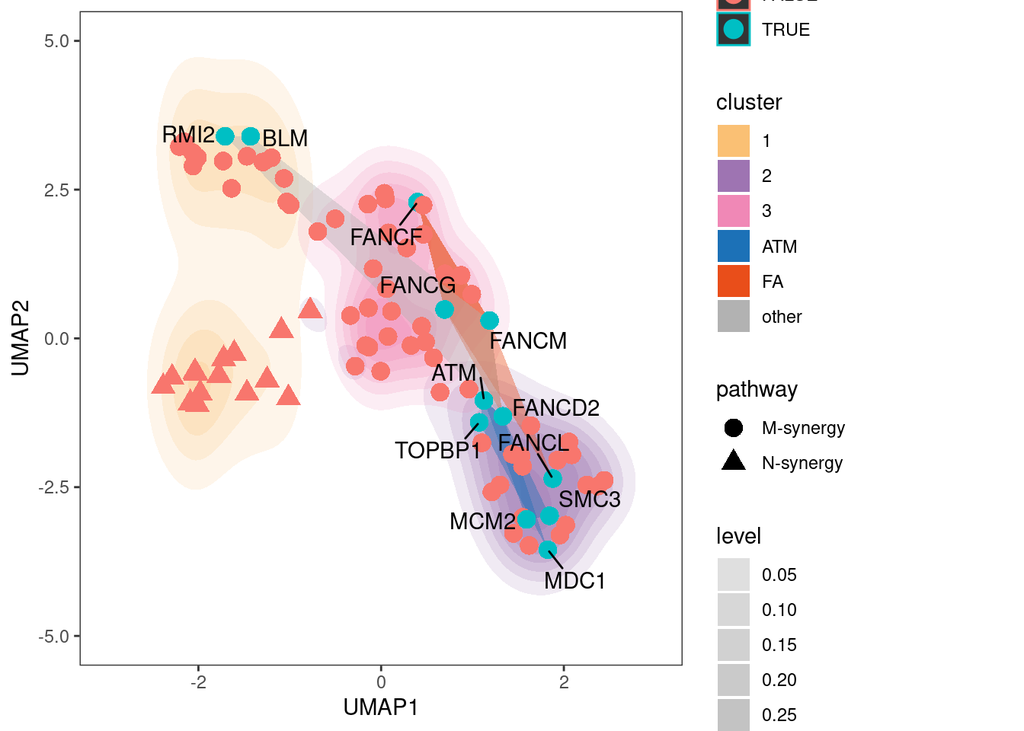

```r
# Clique data table: Summarizing maximum_cliques_data output
all_cliques <- tibble(gene = c("ATM","FANCD2","MDC1","TOPBP1","ATM","FANCD2","SMC3","MCM2","FANCD2","FANCM","FANCF","FANCG","FANCF","FANCG","FANCL","FANCM","BLM","RMI2","FANCD2","FANCM"), clique = c(rep(1,4), rep(2,4),rep(3,4),rep(4,4),rep(5,4)), type = c(rep("ATM",8), rep("FA",8), rep("other",4))) %>% left_join(umap.hits.plot)

#Plot with umap with 4-node cliques
ggplot() +
     stat_density2d(data = umap.hits.plot, geom = "polygon", aes(A,B, fill = cluster, alpha = ..level..), bins = 8) +
     geom_polygon(data = all_cliques, aes(x = A, y = B, group = clique, fill = type), alpha = 0.4) +
     theme_bw() + geom_point(data = umap.hits.plot, aes(A,B, color = gene %in% all_cliques$gene, shape = pathway), size = 4) +
     theme(panel.grid = element_blank()) +
     scale_fill_manual(values = c("#FAC075","#9E75B2","#F088B6","#1D71B8","#E94E1B","#B2B2B2")) + scale_alpha(range = c(0.15,0.3)) +
     geom_text_repel(data = subset(umap.hits.plot, gene %in% all_cliques$gene), aes(A,B,label = gene), force = 40) +
     ylab("UMAP2") + xlab("UMAP1") + ylim(c(-5,5)) + xlim(-3,3)
```

Figure legend: (C) UMAP plot CCDs of DNA repair proteins. Datapoint shape illustrates CCD type and background color illustrates chromatin context they show synergies with. In the figure, all 4-node cliques and proteins involved are highlighted. NOTE: Aesthetics of this graph were modified in illustrator.

# Figure 3D-H: Plot cosine distance tiles

### Data processing

```r
#Select genes in cliques
cosine.cliques.dcast <- slope.protein.features.all %>% filter(gene %in% all_cliques$gene) %>% reshape2::dcast(feature ~ gene, value.var = "CCD_value") %>% column_to_rownames(var = "feature")

#Generate cosine distance matrix
cosine.d.cliques <- cosine(as.matrix(cosine.cliques.dcast)) %>% melt()
```

### Data ploting

#### Figure 3D: ATM clique I

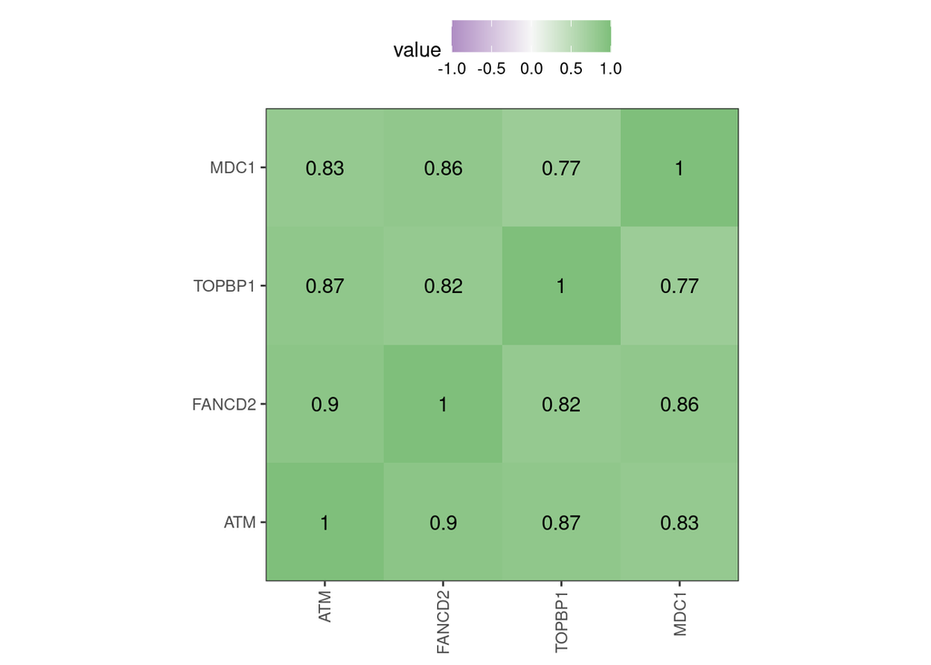

```r
#Clique 1
ggplot(cosine.d.cliques %>% filter(Var1 %in% c("ATM","FANCD2","TOPBP1","MDC1") & Var2 %in% c("ATM","FANCD2","TOPBP1","MDC1"))) +
     geom_tile(aes(fct_relevel(Var1,c("ATM","FANCD2","TOPBP1","MDC1")), fct_relevel(Var2,c("ATM","FANCD2","TOPBP1","MDC1")), fill = value))+
     theme_bw() + theme(axis.text.x = element_text(angle = 90, vjust = 0.5, hjust = 1), legend.position = "top") +
     coord_fixed(expand = F,ratio = 1) + scale_fill_gradient2(low = "#af8dc3", mid = "#f7f7f7", high = "#7fbf7b", limits = c(-1,1)) +
     geom_text(aes(fct_relevel(Var1,c("ATM","FANCD2","TOPBP1","MDC1")), fct_relevel(Var2,c("ATM","FANCD2","TOPBP1","MDC1")),label = round(value, digits = 2))) + theme(axis.title = element_blank())
```

#### Figure 3E: ATM clique II

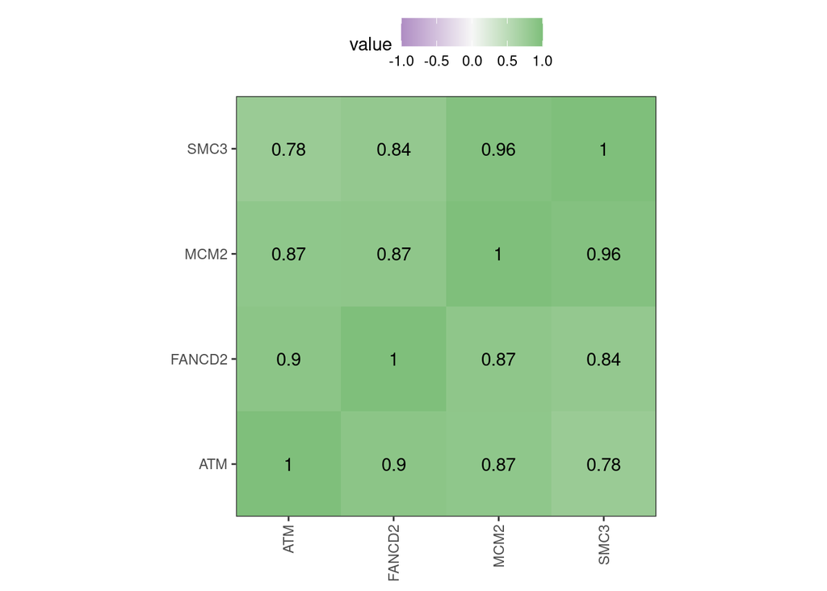

```r
#Clique 2
ggplot(cosine.d.cliques %>% filter(Var1 %in% c("ATM","FANCD2","MCM2","SMC3") & Var2 %in% c("ATM","FANCD2","MCM2","SMC3"))) +
     geom_tile(aes(fct_relevel(Var1,c("ATM","FANCD2","MCM2","SMC3")), fct_relevel(Var2,c("ATM","FANCD2","MCM2","SMC3")), fill = value))+
     theme_bw() + theme(axis.text.x = element_text(angle = 90, vjust = 0.5, hjust = 1), legend.position = "top") +
     coord_fixed(expand = F,ratio = 1) + scale_fill_gradient2(low = "#af8dc3", mid = "#f7f7f7", high = "#7fbf7b", limits = c(-1,1)) +
     geom_text(aes(fct_relevel(Var1,c("ATM","FANCD2","MCM2","SMC3")), fct_relevel(Var2,c("ATM","FANCD2","MCM2","SMC3")),label = round(value, digits = 2))) + theme(axis.title = element_blank())
```

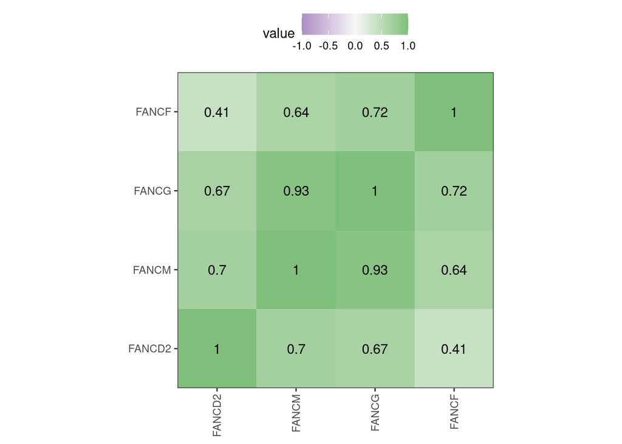

```r
#Clique 3
ggplot(cosine.d.cliques %>% filter(Var1 %in% c("FANCD2","FANCM","FANCG","FANCF") & Var2 %in% c("FANCD2","FANCM","FANCG","FANCF"))) +
     geom_tile(aes(fct_relevel(Var1,c("FANCD2","FANCM","FANCG","FANCF")), fct_relevel(Var2,c("FANCD2","FANCM","FANCG","FANCF")), fill = value))+
     theme_bw() + theme(axis.text.x = element_text(angle = 90, vjust = 0.5, hjust = 1), legend.position = "top") +
     coord_fixed(expand = F,ratio = 1) + scale_fill_gradient2(low = "#af8dc3", mid = "#f7f7f7", high = "#7fbf7b", limits = c(-1,1)) +
     geom_text(aes(fct_relevel(Var1,c("FANCD2","FANCM","FANCG","FANCF")), fct_relevel(Var2,c("FANCD2","FANCM","FANCG","FANCF")),label = round(value, digits = 2))) + theme(axis.title = element_blank())
```

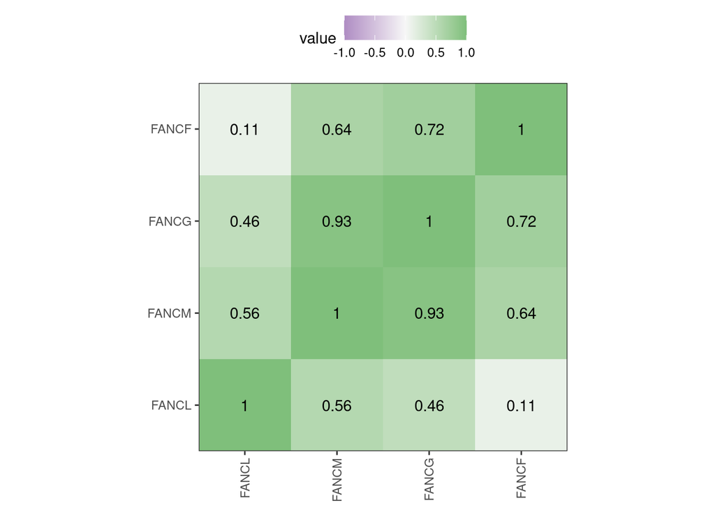

```r
#Clique 4
ggplot(cosine.d.cliques %>% filter(Var1 %in% c("FANCL","FANCM","FANCG","FANCF") & Var2 %in% c("FANCL","FANCM","FANCG","FANCF"))) +
     geom_tile(aes(fct_relevel(Var1,c("FANCL","FANCM","FANCG","FANCF")), fct_relevel(Var2,c("FANCL","FANCM","FANCG","FANCF")), fill = value))+
     theme_bw() + theme(axis.text.x = element_text(angle = 90, vjust = 0.5, hjust = 1), legend.position = "top") +
     coord_fixed(expand = F,ratio = 1) + scale_fill_gradient2(low = "#af8dc3", mid = "#f7f7f7", high = "#7fbf7b", limits = c(-1,1)) +
     geom_text(aes(fct_relevel(Var1,c("FANCL","FANCM","FANCG","FANCF")), fct_relevel(Var2,c("FANCL","FANCM","FANCG","FANCF")),label = round(value, digits = 2))) + theme(axis.title = element_blank())
```

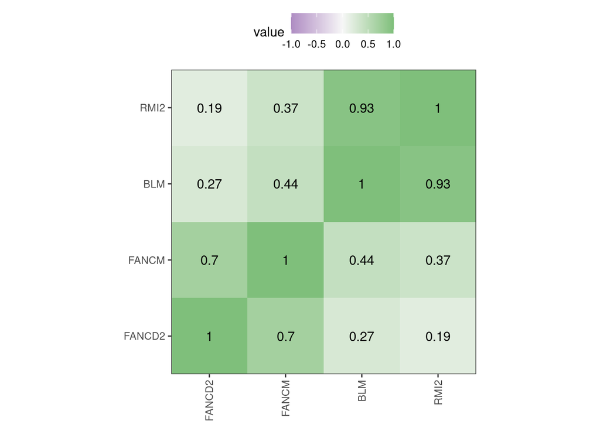

```r
#Clique 4
ggplot(cosine.d.cliques %>% filter(Var1 %in% c("FANCD2","FANCM","BLM","RMI2") & Var2 %in% c("FANCD2","FANCM","BLM","RMI2"))) +
     geom_tile(aes(fct_relevel(Var1,c("FANCD2","FANCM","BLM","RMI2")), fct_relevel(Var2,c("FANCD2","FANCM","BLM","RMI2")), fill = value))+
     theme_bw() + theme(axis.text.x = element_text(angle = 90, vjust = 0.5, hjust = 1), legend.position = "top") +
     coord_fixed(expand = F,ratio = 1) + scale_fill_gradient2(low = "#af8dc3", mid = "#f7f7f7", high = "#7fbf7b", limits = c(-1,1)) +
     geom_text(aes(fct_relevel(Var1,c("FANCD2","FANCM","BLM","RMI2")), fct_relevel(Var2,c("FANCD2","FANCM","BLM","RMI2")),label = round(value, digits = 2))) + theme(axis.title = element_blank())
```

Figure legend: Similarity score tiles between proteins in the same clique: (D) ATM clique I, (E) ATM clique II, (F) FA clique I, (G) FA clique II and (H) mixed clique. All color scales range from -1 to 1.